# BCB546_Assignment

Shirin Parvin

2025-03-19

## R Assignment_BCB546_Spring2025

### Submitted by Shirin Parvin

## Part I

### *Data Inspection*

There are two data files given to us `fang_et_al_genotypes.txt` and `snp_position.txt`. For all the data manipulation necessary, we first call the`tidyverse` library.

```r
#Calling the libraries needed
library(tidyverse)
```

Then, we read the data files into our system and inspect its content.

```r
#Loading the data files in R as dataframes, and inspecting their content such as number of rows, columns column names etc

genotype.df <- read.table("fang_et_al_genotypes.txt", sep = "\t", header = TRUE)
nrow(genotype.df)
```

```
## [1] 2782
```

```r
ncol(genotype.df)
```

```
## [1] 986
```

```r
str(genotype.df)
```

```
## 'data.frame':    2782 obs. of  986 variables:
##  $ Sample_ID     : chr  "SL-15" "SL-16" "SL-11" "SL-12" ...
##  $ JG_OTU        : chr  "T-aust-1" "T-aust-2" "T-brav-1" "T-brav-2" ...
##  $ Group         : chr  "TRIPS" "TRIPS" "TRIPS" "TRIPS" ...
##  $ abph1.20      : chr  "?/?" "?/?" "?/?" "?/?" ...
##  $ abph1.22      : chr  "?/?" "?/?" "?/?" "?/?" ...
##  $ ae1.3         : chr  "T/T" "T/T" "T/T" "T/T" ...
##  $ ae1.4         : chr  "G/G" "?/?" "G/G" "G/G" ...
##  $ ae1.5         : chr  "T/T" "T/T" "T/T" "T/T" ...
##  $ an1.4         : chr  "C/C" "C/C" "?/?" "C/C" ...
##  $ ba1.6         : chr  "?/?" "A/G" "G/G" "G/G" ...
##  $ ba1.9         : chr  "G/G" "G/G" "G/G" "G/G" ...
##  $ bt2.5         : chr  "?/?" "?/?" "C/C" "C/C" ...
##  $ bt2.7         : chr  "A/A" "A/A" "A/A" "A/A" ...
##  $ bt2.8         : chr  "?/?" "?/?" "?/?" "?/?" ...
```

[output cut: 86 more lines]

```r
snp.df <- read.table("snp_position.txt", sep = "\t", header = TRUE)
nrow(snp.df)
```

```
## [1] 983
```

```r
ncol(snp.df)
```

```
## [1] 15
```

```r
str(snp.df)
```

```
## 'data.frame':    983 obs. of  15 variables:
##  $ SNP_ID              : chr  "abph1.20" "abph1.22" "ae1.3" "ae1.4" ...
##  $ cdv_marker_id       : int  5976 5978 6605 6606 6607 5982 3463 3466 5983 5985 ...
##  $ Chromosome          : chr  "2" "2" "5" "5" ...
##  $ Position            : chr  "27403404" "27403892" "167889790" "167889682" ...
##  $ alt_pos             : chr  "" "" "" "" ...
##  $ mult_positions      : chr  "" "" "" "" ...
##  $ amplicon            : chr  "abph1" "abph1" "ae1" "ae1" ...
##  $ cdv_map_feature.name: chr  "AB042260" "AB042260" "ae1" "ae1" ...
##  $ gene                : chr  "abph1" "abph1" "ae1" "ae1" ...
##  $ candidate.random    : chr  "candidate" "candidate" "candidate" "candidate" ...
##  $ Genaissance_daa_id  : int  8393 8394 8395 8396 8397 8398 8399 8400 8401 8402 ...
##  $ Sequenom_daa_id     : int  10474 10475 10477 10478 10479 10481 10482 10483 10486 10487 ...
##  $ count_amplicons     : int  1 0 1 0 0 1 1 0 1 0 ...
##  $ count_cmf           : int  1 0 1 0 0 1 0 0 1 0 ...
##  $ count_gene          : int  1 0 1 0 0 1 1 0 1 0 ...
```

From inspecting the dataframes, we can describe their structure as follows:

1. genotype.df = the dataframe containing the data from `fang_et_al_genotypes.txt`. It has 2782 rows (observations) and 986 columns (variables). Some of its column names are ‘Sample_ID’, ‘Group’, etc
2. snp.df = the dataframe containing the data from `snp_positions.txt`. It has 983 rows (observations) and 15 columns (variables). Some of its column names are ‘SNP_ID’, ‘Chromosome’,‘Position’, ‘alt_pos’,‘mult_positions’, etc

### *Data Processing*

Since we do not need all the data present in the dataframe `snp.df`, we select only the relevant column data (SNP_ID, Chromosome and Position) and store it into a new dataframe `snp_clean.df`.

```r
#Selecting the relevant SNP data only
snp_clean.df <- snp.df[c('SNP_ID','Chromosome','Position')]
```

For ease of use later, we separate out the maize and teosinte data into separate dataframes. Further, we transpose the dataframes and remove the unnecessary rows to facilitate merging of the snp data with the genotype data for data analysis.

```r
#Creating the maize data
maize_data.df <- filter(genotype.df, `Group` %in% c('ZMMIL','ZMMLR','ZMMMR'))
maize_transpose.df <- data.frame(t(maize_data.df))
maize_clean.df <- maize_transpose.df[-c(1:3),]
rownames(maize_clean.df) <- NULL

#Creating the teosinte data
teosinte_data.df <- filter(genotype.df, `Group` %in% c('ZMPBA','ZMPIL','ZMPJA'))
teosinte_transpose.df <- data.frame(t(teosinte_data.df))
teosinte_clean.df <- teosinte_transpose.df[-c(1:3), ]
rownames(teosinte_clean.df) <- NULL
```

After cleaning the individual data sets, I joined the genotype data set with the snp data to create a master data set, which I will use for further analysis. `maize.df` contains the master data set for maize after joining, while `teosinte.df` is the master data set for the teosinte data after joining.

```r
#Creating the master datasets
maize.df <- cbind(snp_clean.df,maize_clean.df)
teosinte.df <- cbind(snp_clean.df,teosinte_clean.df)
```

Now we will try to generate the files requested in the assignment. We will deal with the Maize and Teosinte data separately for ease of data handling. Only con is that we will generate a lot of intermediate and final objects.

#### Maize data

First, we deal with the Maize data. In file set 1, we are suppsed to generate 10 files, each corresponding to a chromosome, in which the positions are sorted in increasing order and the missing value is encoded by the ‘?’ symbol. Here, we define a function `write_maize_data` that filters out the data for each chromosome and then saves the data into a new file with a unique name. We then use the `lapply` function to repeat this function for all the chromosomes.

```r
#Maize data

#Set 1:

#SNPs ordered in increasing position with missing values encoded by '?' symbol
maize_sorted.df <- maize.df %>%
  arrange (as.numeric(Chromosome),as.numeric(Position))
#Generating the file set:
#Step 1: Selecting each unique chromosome
maize_chrom.l <- unique(maize_sorted.df$Chromosome)

#Step 2: Defining a function to write a dataframe for the selected chromosome
write_maize_data <- function(chrom_num)
  {
  maize_chrom_data.df <- filter(maize_sorted.df, Chromosome == chrom_num)
  file_name <- paste0('maize_chr_',chrom_num,'.txt')
  write.table (maize_chrom_data.df, file = file_name, quote = FALSE, sep = '\t', row.names = FALSE, col.names = TRUE)
}

#Step 3: Applying Step 2 to all chromosomes
lapply (maize_chrom.l, write_maize_data)
```

For file set 2, we need to replace the encoding of the missing data by the ‘-’ symbol and sort the position in descending order, for each chromosome. We need to generate 10 files, corresponding to each chromosome. Similar to before, we define a `write_maize_rev_data` function to help facilitate this. The generated files are saved with their unique names.

```r
#Set 2

#SNPs ordered in decreasing position with missing values encoded by '-' symbol

maize_rev_sorted.df <- maize.df %>%
  arrange (as.numeric(Chromosome),desc(as.numeric(Position)))   #sorting in decreasing order
maize_rev_sorted.df[maize_rev_sorted.df == '?/?'] <- '-/-'    #replacing the '?' with '-'

#Generating the file set:
#Step 1: We are reusing the list of chromosomes generated in first set since the chromosome number did not change
maize_chrom.l <- unique(maize_sorted.df$Chromosome)

#Step 2: Defining a function to write a dataframe for the selected chromosome

write_maize_rev_data <- function(chrom_num)
  {
  maize_chrom_rev_data.df <- filter(maize_rev_sorted.df, Chromosome == chrom_num)
  file_name <- paste0('maize_rev_chr_',chrom_num,'.txt')
  write.table (maize_chrom_rev_data.df, file = file_name, quote = FALSE, sep = '\t', row.names = FALSE, col.names = TRUE)
}

#Step 3: Applying Step 2 to all chromosomes
lapply (maize_chrom.l, write_maize_rev_data)
```

#### Teosinte data

After the maize data, we deal with the Teosinte data. Just like above, in file set 1, we are suppsed to generate 10 files, each corresponding to a chromosome, in which the positions are sorted in increasing order and the missing value is encoded by the ‘?’ symbol. Correspondinly, we define a function `write_teo_data` that filters out the data for each chromosome and then saves the data into a new file with a unique name. We then use the `lapply` function to repeat this function for all the chromosomes.

```r
#Teosinte data

#Set 1:

#SNPs ordered in increasing position with missing values encoded by '?' symbol
teosinte_sorted.df <- teosinte.df %>%
  arrange (as.numeric(Chromosome),as.numeric(Position))
#Generating the file set:
#Step 1: Selecting each unique chromosome
teo_chrom.l <- unique(teosinte_sorted.df$Chromosome)


#Step 2: Defining a function to write a dataframe for the selected chromosome
write_teo_data <- function(chrom_num)
  {
  teosinte_chrom_data.df <- filter(teosinte_sorted.df, Chromosome == chrom_num)
  file_name <- paste0('teo_chr_',chrom_num,'.txt')
  write.table (teosinte_chrom_data.df, file = file_name, quote = FALSE, sep = '\t', row.names = FALSE, col.names = TRUE)
}

#Step 3: Applying Step 2 to all chromosomes
lapply (teo_chrom.l, write_teo_data)
```

Again, for file set 2, we need to replace the encoding of the missing data by the ‘-’ symbol and sort the position in descending order, for each chromosome. We need to generate 10 files, corresponding to each chromosome. Similar to before, we define a `write_teo_rev_data` function to help facilitate this. The generated files are saved with their unique names.

```r
#Set 2

#SNPs ordered in decreasing position with missing values encoded by '-' symbol

teo_rev_sorted.df <- teosinte.df %>%
  arrange (as.numeric(Chromosome),desc(as.numeric(Position)))   #sorting in decreasing order
teo_rev_sorted.df[teo_rev_sorted.df == '?/?'] <- '-/-'    #replacing the '?' with '-'

#Generating the file set:
#Step 1: We are reusing the list of chromosomes generated in first set since the chromosome number did not change
teo_chrom.l <- unique(teosinte_sorted.df$Chromosome)

#Step 2: Defining a function to write a dataframe for the selected chromosome

write_teo_rev_data <- function(chrom_num)
  {
  teo_chrom_rev_data.df <- filter(teo_rev_sorted.df, Chromosome == chrom_num)
  file_name <- paste0('teo_rev_chr_',chrom_num,'_rev.txt')
  write.table (teo_chrom_rev_data.df, file = file_name, quote = FALSE, sep = '\t', row.names = FALSE, col.names = TRUE)
}

#Step 3: Applying Step 2 to all chromosomes
lapply (teo_chrom.l, write_teo_rev_data)
```

## Part II

### *Data Visualization*

For data visualization, we first call the necessary libraries: `ggplot` and `viridis`.

```r
#Calling the libraries needed
library(ggplot2)
library(viridis)
```

This data visualisation part will consist of three parts: 1. SNPs per Chromosome 2. Missing data and amount of heterozygosity 3. My own visualization.

To help with the visualization, we will be using the `pivot_longer()` function to reshape the data. For ease of data handling, I will continue to use the two individual data sets for maize and teosinte and NOT combine them into a master dataset.

### SNPs per Chromosome

#### Maize data

First, we manipulate and look into the Maize dataset. Plot 1 will show the distribution of SNPs along the different positions of each chromosome and will show that for all the chromosomes.

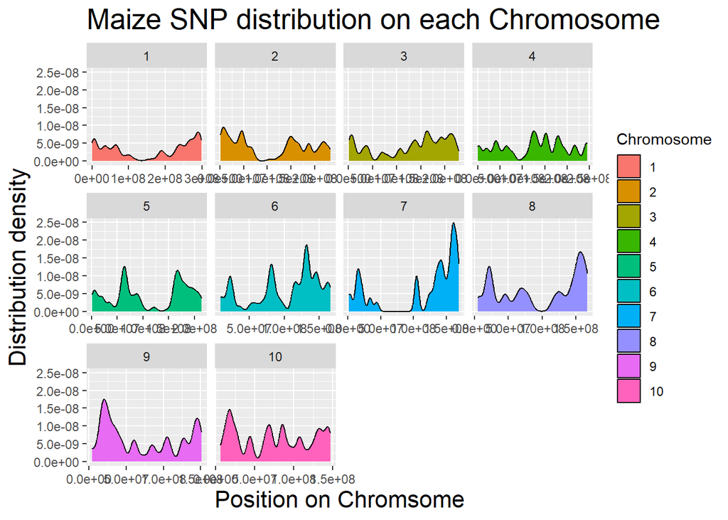

```r
# Maize Data

#Reshaping the data to help facilitate plotting analysis

maize_pivot.df <- pivot_longer(maize_sorted.df, cols = -c(SNP_ID,Chromosome,Position), names_to = NULL, values_to = 'Genotype')

#Converting the Chromosome and Position to numeric values for easier plotting
maize_pivot.df$Chromosome <- as.numeric(maize_pivot.df$Chromosome)
maize_pivot.df$Position <- as.numeric(maize_pivot.df$Position)
# Final Maize SNP data used for visualisation
maize_SNP.df <- maize_pivot.df %>% drop_na()


#Plotting the distribution of SNPs on and across Chromosome

ggplot(data = maize_SNP.df) +
  geom_density(mapping = aes(x = Position, fill = factor(Chromosome))) +
  facet_wrap( ~ factor(Chromosome), scales = "free_x") +
  scale_fill_discrete() +
  labs (title = 'Maize SNP distribution on each Chromosome',
        x = 'Position on Chromsome',
        y = 'Distribution density',
        fill = 'Chromosome') +
  theme( plot.title = element_text(size = 20),
         axis.title.x = element_text(size = 16),
         axis.title.y = element_text (size = 16)
  )
```

Further we also summarized the number of SNPs in each chromosome and plotted them to get a better idea of what is happening.

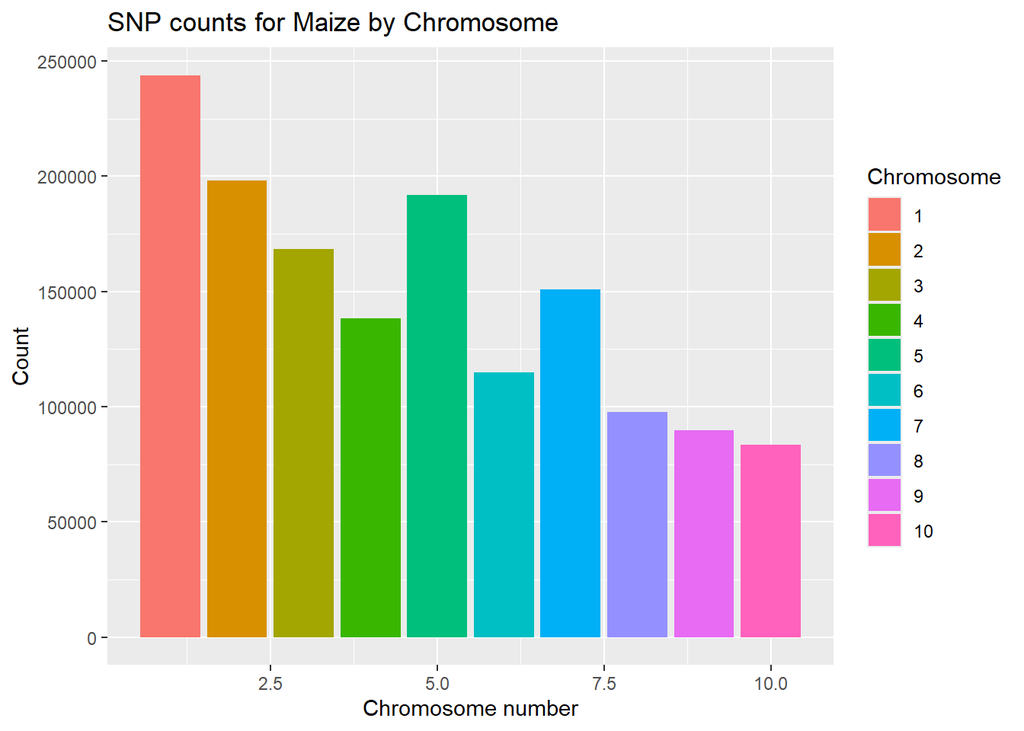

```r
# Calculating and plotting the number of Maize SNP across chromosome

maize_result.df <- maize_SNP.df %>%
  group_by(Chromosome) %>%
  summarise(SNP_count = n())


ggplot(maize_result.df) +
  geom_bar(mapping = aes(x = Chromosome, y = SNP_count,fill = factor( Chromosome)), stat = 'identity') + scale_fill_discrete() +
  labs(title = "SNP counts for Maize by Chromosome",
       x = "Chromosome number",
       y = "Count",
       fill = "Chromosome")
```

#### Teosinte data

Next, we manipulate and look into the Teosinte dataset. Again, Plot 1 will show the distribution of SNPs along the different positions of each chromosome and will show that for all the chromosomes.

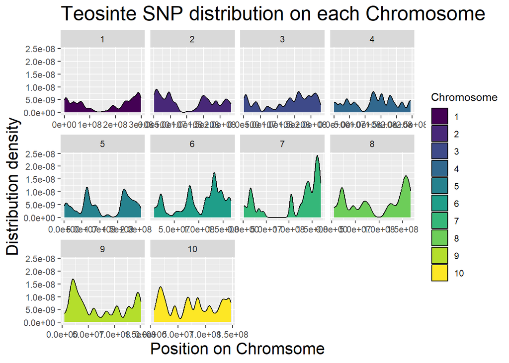

```r
# Teosinte Data

#Reshaping the data to help facilitate plotting analysis

teo_pivot.df <- pivot_longer(teosinte_sorted.df, cols = -c(SNP_ID,Chromosome,Position), names_to = NULL, values_to = 'Genotype')

#Converting the Chromosome and Position to numeric values for easier plotting
teo_pivot.df$Chromosome <- as.numeric(teo_pivot.df$Chromosome)
teo_pivot.df$Position <- as.numeric(teo_pivot.df$Position)
# Final Teosinte SNP data used for visualisation
teo_SNP.df <- teo_pivot.df %>% drop_na()



#Plotting the distribution of SNPs on and across Chromosome

ggplot(data = teo_SNP.df) +
  geom_density(mapping = aes(x = Position, fill = factor(Chromosome))) +
  facet_wrap( ~ factor(Chromosome), scales = "free_x") +
  scale_fill_viridis_d() +
  labs (title = 'Teosinte SNP distribution on each Chromosome',
        x = 'Position on Chromsome',
        y = 'Distribution density',
        fill = 'Chromosome') +
  theme( plot.title = element_text(size = 20),
         axis.title.x = element_text(size = 16),
         axis.title.y = element_text (size = 16)
  )
```

Further we also summarized the number of SNPs in each chromosome and plotted them to get a better idea of what is happening.

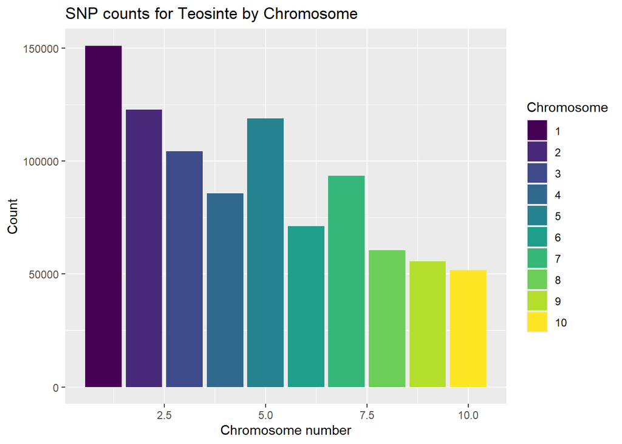

```r
# Calculating and plotting the number of Maize SNP across chromosome

teo_result.df <- teo_SNP.df %>%
  group_by(Chromosome) %>%
  summarise(SNP_count = n())


ggplot(teo_result.df) +
  geom_bar(mapping = aes(x = Chromosome, y = SNP_count,fill = factor( Chromosome)), stat = 'identity') + scale_fill_viridis_d() +
  labs(title = "SNP counts for Teosinte by Chromosome",
       x = "Chromosome number",
       y = "Count",
       fill = "Chromosome")
```

Next, we wanted to compare which among the two datasets: Maize and Teosinte had more number of SNP positions. First we calculated it.

```r
# Comparing number of SNP positions in maize and teosinte individuals

maize_total_SNP = sum(maize_result.df$SNP_count)
teo_total_SNP = sum(teo_result.df$SNP_count)

if (maize_total_SNP > teo_total_SNP){
  print(" Maize individuals has more SNP positions")
}else if (teo_total_SNP > maize_total_SNP){
  print (" Teosinte individuals has more SNP positions")
}else {
  print (" Maize and Teosinte individuals have same number of SNP positions")
}
```

```
## [1] " Maize individuals has more SNP positions"
```

Next we confirmed our conclusion from the calculation by visualising the two datasets and their corresponging SNP frequencies.

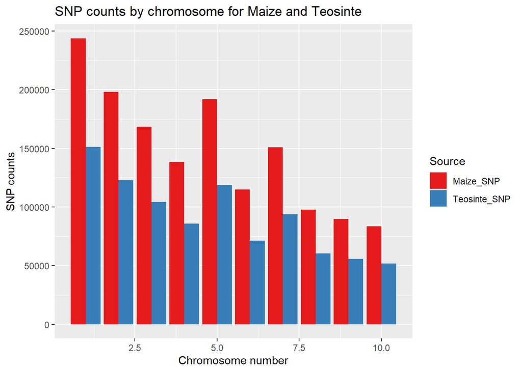

```r
#Plotting the SNP counts for visual confirmation
combined_data <- rbind(
  maize_result.df %>% mutate(Source = "Maize_SNP"),
  teo_result.df %>% mutate(Source = "Teosinte_SNP")
)

ggplot (data = combined_data,
        aes(x = Chromosome, y = SNP_count, fill= Source)) +
  geom_bar(stat = 'identity', position = 'dodge') +
  labs (title = "SNP counts by chromosome for Maize and Teosinte",
        x = "Chromosome number",
        y = "SNP counts") +
  scale_fill_brewer(palette = "Set1")
```

### Missing data and amount of heterozygosity

Next we are interested in investigating what proportions of the SNPs belong to different zygosity and also will look into the amount of missing data we have for each dataset.

Like always, we first look into the Maize data and plot the proportion of zygosity.

[figure not shown]

```r
# Adding Zygosity to Maize SNP data

maize_SNP.df$Zygosity <- ifelse (maize_SNP.df$Genotype %in%
                                   c('A/A','C/C','G/G','T/T'), 'Homozygous',
                                 ifelse(maize_SNP.df$Genotype == '?/?', 'Missing','Heterzygous'))

# Plotting proportion of Maize zygosity
ggplot(data = maize_SNP.df) +
  geom_bar(mapping = aes(x = SNP_ID, fill = Zygosity), position = "fill") +
  labs(title = "Zygosity proportion of Maize samples",
       x = "Each line is a sample",
       y = "Proportion of zygosity") +
  theme(plot.title = element_text(size = 20),
        axis.text.x = element_blank(),
        axis.title.x = element_text(size = 16),
        axis.title.y = element_text(size = 16))
```

Next, we look into the Teosinte data and plot the proportion of zygosity.

[figure not shown]

```r
# Adding Zygosity to Teosinte SNP data

teo_SNP.df$Zygosity <- ifelse (teo_SNP.df$Genotype %in%
                                   c('A/A','C/C','G/G','T/T'), 'Homozygous',
                                 ifelse(teo_SNP.df$Genotype == '?/?', 'Missing','Heterzygous'))

# Plotting proportion of Teosinte zygosity
ggplot(data = teo_SNP.df) +
  geom_bar(mapping = aes(x = SNP_ID, fill = Zygosity), position = "fill") +
  labs(title = "Zygosity proportion of Teosinte samples",
       x = "Each line is a sample",
       y = "Proportion of zygosity") +
  theme(plot.title = element_text(size = 20),
        axis.text.x = element_blank(),
        axis.title.x = element_text(size = 16),
        axis.title.y = element_text(size = 16)) +
  scale_fill_brewer(palette = "Set2")
```

### My own visualization

As part of my own visualization, I was interested to see what heterzygosities are more prevalent on each chromosome and across the different chromosomes in Maize. While, I have only visualized it for Maize, we can perform similar visualization for the Teosinte data. This was interesting and gave me insights into the different trends of heterozygosity in different chromosomes. If we were to know that a certain chromosome is related to a particular phenotype, we could further look into the trends of heterozygosity in that chromosome.

```r
# Want to visualize which SNP is most prevalent among the heterzygotes on and across the chromsomes in Maize

maize_heter.df <- filter(maize_SNP.df, maize_SNP.df$Zygosity == 'Heterzygous') %>%
  group_by(Chromosome,Genotype) %>%
  summarise(SNP_count = n())
```

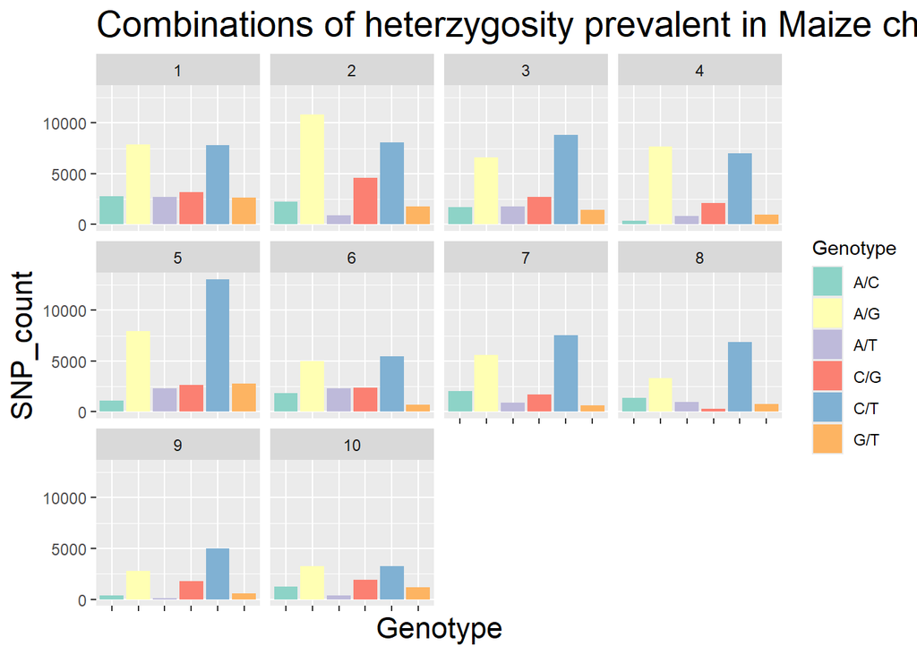

```r
ggplot(data = maize_heter.df) +
  geom_col(mapping = aes(x = Genotype, y = SNP_count, fill = Genotype)) +
  facet_wrap(~factor(Chromosome)) +
  scale_fill_brewer(palette = "Set3") +
  labs(title = "Combinations of heterzygosity prevalent in Maize chromosome",
       x = "Genotype",
       y = "SNP_count") +
  theme(axis.text.x = element_blank(),
        axis.title.x = element_text(size = 16),
        axis.title.y = element_text(size = 16),
        plot.title = element_text(size = 20)
  )
```